# Restructuring Movement

# Restructuring movement

## Goal

Our goal is to estimate movement among polygons over a defined period of time using a BirdFlow model.

The result will be a square movement matrix where the rows correspond to starting polygons and the columns to ending polygons. Values are the proportion of the total population making each movement, which can be scaled to represent numbers of birds. Optionally each value can be adjusted by the area of the two associated polygons to get a mean movement per square kilometer.

The initial motivation to create this workflow was to model how migratory wild birds might contribute to the spread of highly pathogenic avian influenza (HPAI H5N1) among cattle in the United States. Researchers used viral gene sequences to create a phylogeny of the outbreak and infer interstate movements. They wanted to add a predictor of wild bird movement rates to their model of viral movement.

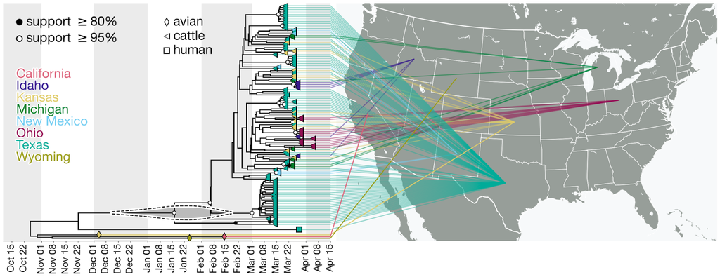

Time-calibrated phylogeny of H5N1 2.3.4.4b genome segment HA. Each genome is connected to the available geographic location in the United States. One genome sampled in the United States does not have state-level resolution and is colored the same as other genomes in North America. Violin centered on the most recent common ancestor (MRCA) of the viruses sampled in cattle represents the 95% highest posterior density (HPD) of the time of this most recent common ancestor (tMRCA).

Figure 4 from Worobey, M., et al. 2024. [Preliminary report on genomic epidemiology of the 2024 H5N1 influenza A virus outbreak in U.S. cattle (Part 1 of 2)](https://virological.org/t/preliminary-report-on-genomic-epidemiology-of-the-2024-h5n1-influenza-a-virus-outbreak-in-u-s-cattle-part-1-of-2/970). *Virological*, 3 May 2024.

In the example here the polygons are US States, but the variable (`polys`) and the sole required column name (`id`) are kept deliberately generic so the code will work with any set of polygons.

### The approach:

1. Load model, set start and end times for connectivity window, and set total population.
2. Load and prepare state polygons
3. Calculate the overlap between active cells in the BirdFlow model and the states.
4. Generate starting distributions for each state that represent the portion of the overall species distribution that is in each state at the start of the movement.
5. Run `predict()` using distributions and start and end time, to project each state’s portion of the population forward.
6. Drop time dimension from result preserving just the end distributions.
7. Convert the ending distribution from model cells to states.
8. Optionally, multiply by the species’ total population (within the Americas) to convert from proportion of population to estimated number of birds
9. Optionally, divide by the area of both the starting and ending state to make the estimates per unit area - eliminating the polygon size as a factor in the connectivity. This step is not appropriate for all use cases.

## Load model and set parameters

This example uses the American Woodcock dataset from the default model collection.

```r
bf <- load_model("amewoo")
start <- BirdFlowR::lookup_timestep("2024-01-15", bf)
end <- BirdFlowR::lookup_timestep("2024-03-20", bf)
population <- 3500000
```

## Load Polygons

Load state boundaries distributed with the BirdFlowModels package.

If you have a polygon shapefile already you could use `polys <- sf::read_sf(shapefile_path)` and skip this section.

```r
# Load state boundaries
polys <- BirdFlowModels::states
```

## Prepare polygons

- Add an `id` field; in this example it is the state names.
- Transform to match the BirdFlow Coordinate Reference System (CRS).
- Calculate the area in square kilometers of each polygon (`sq_km`).
- Add centroid coordinates (`x`, `y`) in the BirdFlow CRS.

```
#> ℹ Adding new coordinate system, which will replace the existing one.
```

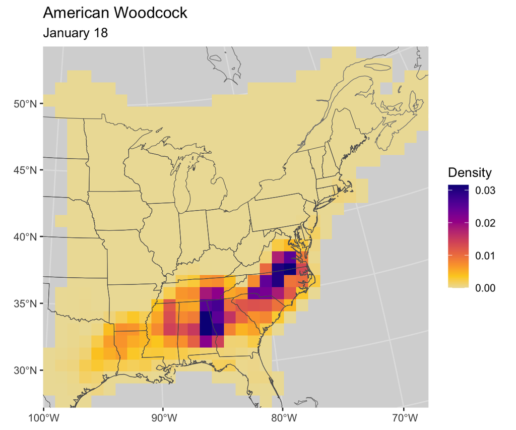

```r
# Add generic "id" column (use state name)
polys$id <- polys$name

# Sort by id
polys <- polys[order(polys$id), ]

# Transform to match the BirdFlow model CRS
polys <- sf::st_transform(polys, crs(bf))

# Calculate area in sq_km
# This assumes the projection is in meters which is true for BirdFlow models
polys$sq_km <- as.vector(sf::st_area(polys)) / 1000^2

# Add centroids (only used for the plotting at end of document)
centroids <- sf::st_centroid(polys[, "geometry"]) |> sf::st_coordinates()
colnames(centroids) <- c("x", "y")
polys <- cbind(polys, centroids)

# Visualize over starting distribution
plot_distr(get_distr(bf, start), bf) +
  geom_sf(data = polys, inherit.aes = FALSE, fill = NA) +
  coord_sf(xlim = c(xmin(bf), xmax(bf)), ylim = c(ymin(bf), ymax(bf)), expand = FALSE)
```

## Calculate overlap between active BirdFlow cells and polygons

Make the `overlap` matrix. Rows correspond to BirdFlow active cells, and columns to the state polygons. The values are the proportion of the cell that overlaps the polygon.

```r
# Convert active cells to polygons
cell_polys <- rasterize_distr(seq_len(n_active(bf)), bf, format = "terra") |>
 terra::as.polygons() |>
  sf::st_as_sf()
names(cell_polys)[1] <- "i" # BirdFlow location index "i"

# Intersect cells with states
suppressWarnings( # Attribute values assumed to be spatially constant...
  intersection_polys <- sf::st_intersection(cell_polys, polys)
)
intersection_polys <- intersection_polys[, c("i", "id")]
intersection_polys$area <- sf::st_area(intersection_polys)
sq_m_per_cell <- prod(res(bf))
intersection_polys$prop_of_cell <- intersection_polys$area / sq_m_per_cell

# Calculate the proportion of each cell that overlaps each polygon
# Rows = active cells, columns = polygons
overlap <- matrix(0, nrow = n_active(bf), ncol = nrow(polys),
                  dimnames = list(i = seq_len(n_active(bf)),
                                  id = polys$id))
intersection_polys$row <- match(intersection_polys$i, seq_len(n_active(bf)))
intersection_polys$col <- match(intersection_polys$id, polys$id)
row_col_index <- intersection_polys[, c("row", "col")] |>
  sf::st_drop_geometry() |>
  as.matrix()
overlap[row_col_index] <- intersection_polys$prop_of_cell |> as.vector()
```

## Build initial distributions

This essentially clips the initial distribution separately to each polygon while assigning values from boundary cells in proportion to their overlap with the polygon.

Note, a single BirdFlowR distribution is a vector of length `n_active(bf)`; multiple distributions can be stored in a matrix with `n_active(bf)` rows. The matrix here has a column (distribution) for each polygon in `polys`.

```r
# Create starting distribution matrix with a column for each state
# Initially each state has the full distribution for the species
start_distr <- matrix(get_distr(bf, start),
                              nrow = n_active(bf),
                              ncol = nrow(polys),
                              byrow = FALSE,
                              dimnames = list(i = seq_len(n_active(bf)),
                             start_poly = polys$id))

# Multiply by each State's overlap to clip out just the values for each state.
start_distr <- start_distr * overlap
```

```
#> North Carolina        Alabama        Georgia       Virginia      Tennessee
#>     0.18801061     0.17634704     0.15274257     0.10194005     0.08209629
#> South Carolina
#>     0.08095770
```

### Visualize the distribution for one polygon

Visualize the initial distribution for the polygon with the highest initial abundance (North Carolina).

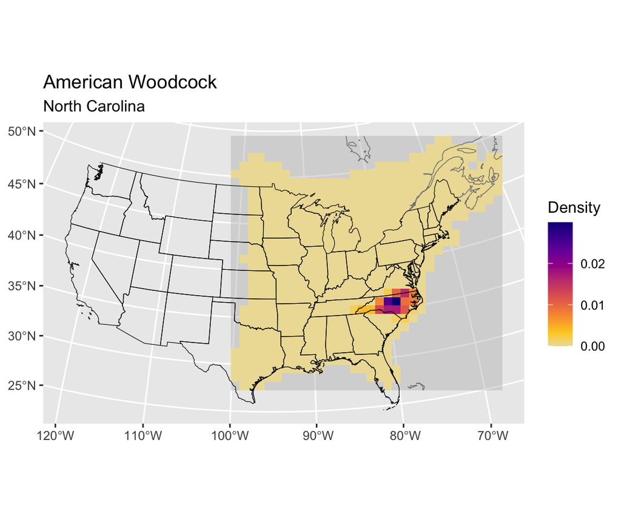

```r
plot_distr(start_distr, bf, subset = sel) +
  ggplot2::geom_sf(data = polys,
                   inherit.aes = FALSE,
                   linewidth = 0.2,
                   color = "black",
                   fill = NA)
```

## Project the distributions forward

Use `BirdFlowR::predict()` to project the distributions forward. With multiple input distributions the output will be a three dimensional array. Select the last element of the third dimension to get just the ending distributions in a matrix. The values in these distributions represent the proportion of the population that started in the corresponding polygon (columns) that ended in each active cell (rows).

```r
# Project distributions forward to end date
pred <- predict(bf, distr = start_distr, start = start, end = end)

# Just keep last distribution
end_distr <- pred[, , dim(pred)[3]]

# Restore dimension names
dimnames(end_distr) <- dimnames(start_distr)
```

### Visualize the ending distribution

This shows the ending distribution for the birds that started in North Carolina.

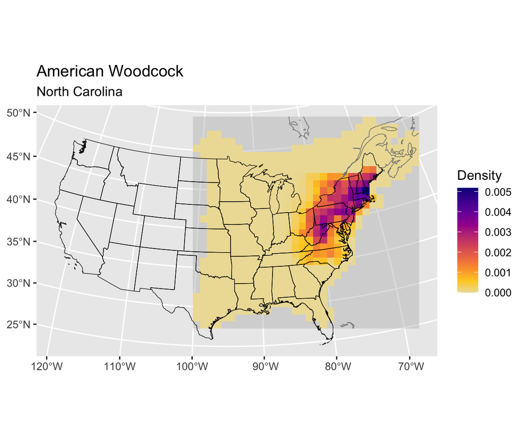

```r
plot_distr(end_distr, bf, sel) +
  ggplot2::geom_sf(data = polys,
                   inherit.aes = FALSE,
                   linewidth = 0.2,
                   color = "black",
                   fill = NA)
```

## Collapse the ending cells into ending polygons

Convert the `end_distr` destination cells into destination polygons based on the overlap proportions in `overlap`.

The result is `move`: a matrix with rows for starting polygons, columns for destination polygons, and values that are the proportion of the total population making each transition.

```r
# Each entry move[from, to] is the proportion of the total population
# that started in polygon "from" and ended in polygon "to".
move <- t(end_distr) %*% overlap
dimnames(move) <- list(from = polys$id, to = polys$id)
```

### Visualize the polygonized end distribution

Plot the proportion of the total population that moved from North Carolina to each state.

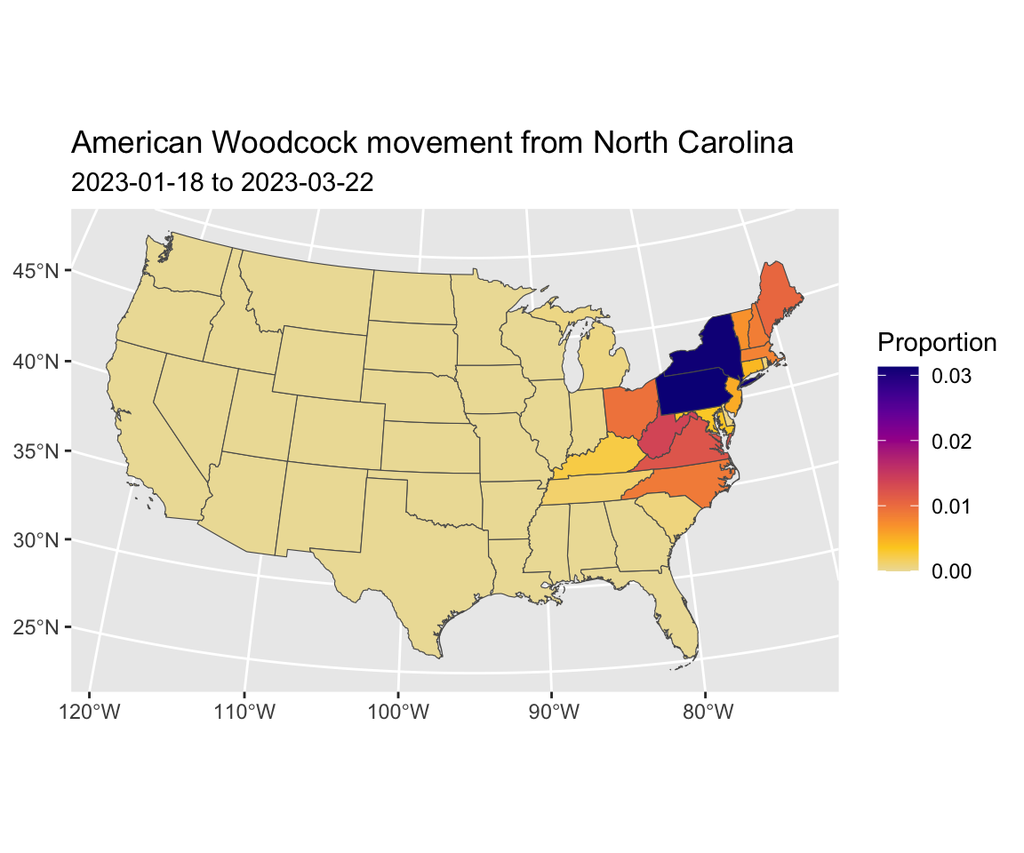

```r
polys$Proportion  <- move[sel, ]

gradient_colors <-
      c("#EDDEA5", "#FCCE25", "#FBA238", "#EE7B51", "#DA596A", "#BF3984",
        "#9D189D", "#7401A8", "#48039F", "#0D0887")

ggplot2::ggplot(data = polys) +
  ggplot2::geom_sf(ggplot2::aes(fill = Proportion)) +
  ggplot2::scale_fill_gradientn(colors = gradient_colors) +
  ggplot2::ggtitle(paste0(species(bf), " movement from ", polys$id[sel]),
                   subtitle = paste0(lookup_date(start, bf), " to ",
                                     lookup_date(end, bf)))
```

## Adjust for population (optional)

You can multiply the movement by the total population of the species to estimate the number of individuals making each movement. This is likely necessary to aggregate or compare output across species.

```r
# Convert to absolute numbers of Birds expected to move between
# each pair of polygons
move_count  <- move * population
```

## Adjust for area (optional)

Adjusting for area might be appropriate depending on the application. If the goal is to capture the total magnitude of movement between each source and destination polygon then do not adjust for area.

However, in our initial use case our points were in the specified states but did not represent the entire state so failing to adjust for state area would introduce a bias - essentially inflating movement for points that fell in bigger states. Similarly if you want an average per unit area movement between states that isn’t biased by state area you would adjust for area.

The adjustment is done by dividing the number of individuals moving between the two polygons by the area of each polygon in sq km to produce the expected number to move between them per sq km at each end. Clearly, though, this does not capture the fine scale variability within them, some of which is captured in the original BirdFlow cells.

```r
# Adjust for area of both the source and destination polygons
n <- nrow(polys)
from_area <- matrix(polys$sq_km, n, n, byrow = FALSE)
to_area <- matrix(polys$sq_km, n, n, byrow = TRUE)
move_area <- move_count / from_area / to_area
```

## Visualize movement

```r
plot_count_threshold <- 1000 # only plot lines for big movements
```

Plot non-zero estimated counts of birds moving between polygons and indicate magnitude with line thickness. Lines are only shown for movements of at least 1000 individuals.

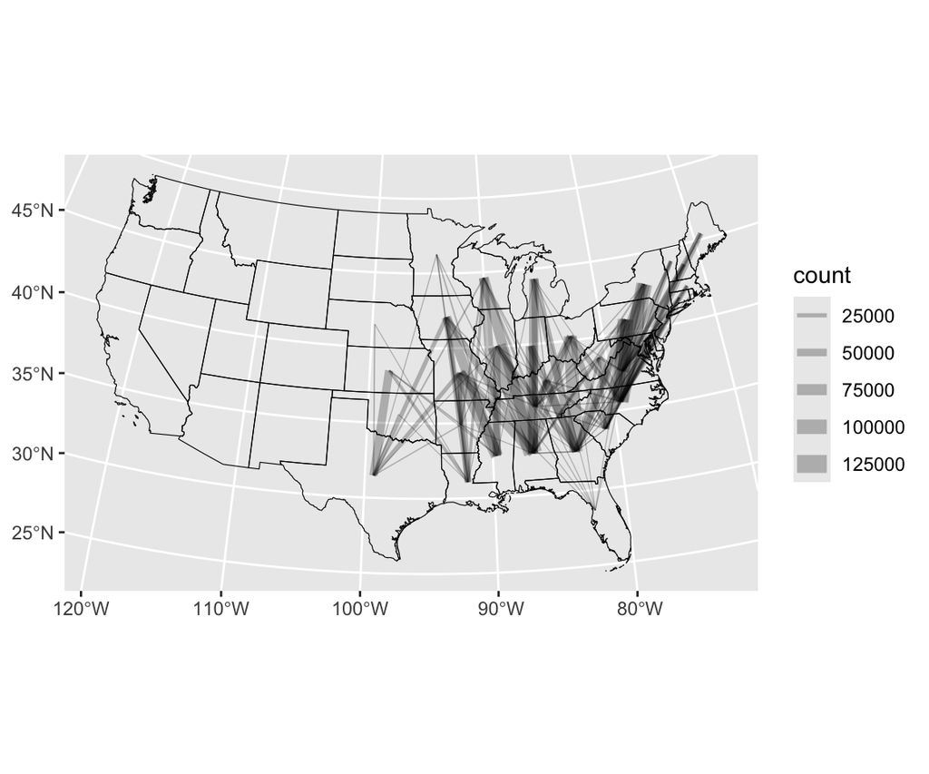

```r
n <- nrow(polys)
long <- data.frame(from =  rep(polys$id, times = n),
                   to = rep(polys$id, each = n),
                   count = as.vector(move_count))

# Add coordinates of centroids of to and from polygons

coords <- select(polys, "id", "x", "y") |>
  sf::st_drop_geometry()

# Add from coordinates
long <- left_join(long, coords, join_by(from == id)) |> rename(f_x = x, f_y = y)

# Add to coordinates
long <- left_join(long, coords, join_by(to == id)) |> rename(t_x = x, t_y = y)

long <- long[long$count >= plot_count_threshold, ]

ggplot2::ggplot(long) +
  ggplot2::geom_segment(ggplot2::aes(x = f_x, y = f_y,
                                     xend = t_x, yend = t_y,
                                     linewidth = count),
                        color = rgb(0, 0, 0, .25)) +
  ggplot2::scale_linewidth(range = c(0.2, 4)) +
  ggplot2::theme(axis.title = ggplot2::element_blank(),
                 strip.background = ggplot2::element_blank()) +
  ggplot2::geom_sf(data = polys,
                   inherit.aes = FALSE,
                   linewidth = 0.2,
                   color = "black",
                   fill = NA)
```

## Exercises

### 1. Change the time window and/or species

`start` and `end` are the only things that define the movement period.

1. Re-run with a fall window (say 2024-09-01 to 2024-11-15). How does the pattern change?
2. Try another species. Use `load_collection_index() |> select("species_code", "common_name")` to list available models.
3. Instead of hard-coded dates, use a named season. `predict()` passes its time arguments through to `lookup_timestep_sequence()`, so `season = "prebreeding"` works in place of `start` and `end`.

### 2. Understand the movement matrix

1. What does `sum(move)` equal, and why? What about `sum(move[sel, ])`?
2. What do the diagonal entries `diag(move)` represent? For this species and time window, is most of the population staying put or moving between states?
3. Row sums and column sums answer two different questions. Which is “where did the birds in this state go?” and which is “where did the birds now in this state come from?”

```r
sum(move)
```

```
#> [1] 0.8497029
```

```r
sum(diag(move)) / sum(move)   # proportion staying in their starting state
```

```
#> [1] 0.05159543
```

```r
head(sort(rowSums(move), decreasing = TRUE))
```

```
#> North Carolina        Alabama        Georgia       Virginia    Mississippi
#>     0.15954644     0.15837211     0.12106149     0.09086425     0.07799780
#>      Tennessee
#>     0.06795789
```

### 3. Net movement between states

The matrix is not symmetric — `move["North Carolina", "Michigan"]` need not equal `move["Michigan", "North Carolina"]`. Compute the net exchange and find the biggest net exporters and importers of birds over this window.

```r
net <- move - t(move)          # net[i, j] = net flow from i to j
net_out <- rowSums(net)        # positive = net exporter
```

Which states have the largest net outflow? Does that match what you know about American Woodcock migration in late winter?

### 4. Does the area adjustment change your conclusions?

Rank the top 20 movements by `move_count`, then again by `move_area`, and compare the two lists.

1. Which states enter the top 20 only after adjusting for area? Which drop out?
2. For the HPAI use case described in the overview — sampled points within states, not whole states — which ranking is the appropriate one, and why?

## Solutions

### 1. Rerun with other parameters

Change the lines 91:93 and rerun. The result will depend on the time frame and species you pick.

### 2. Understand the movement matrix

**a. `sum(move)` is *not* 1.**

```r
sum(get_distr(bf, start))   # the model distribution does sum to 1
```

```
#> [1] 1
```

```r
sum(start_distr)            # after clipping to states
```

```
#> [1] 0.9720035
```

```r
sum(move)                   # after projecting and collapsing to states
```

```
#> [1] 0.8497029
```

Density is lost at two separate points, and both are due to polygon coverage:

1. **At the start.** `start_distr <- start_distr * overlap` keeps only the share of each cell that falls inside some state. Cells over Canada, Mexico, and the ocean are zeroed, so `sum(start_distr) < 1`.
2. **At the end.** `move <- t(end_distr) %*% overlap` applies the same clipping to the destinations. Birds that ended outside the polygon set are dropped.

`predict()` itself conserves density — `sum(end_distr)` equals `sum(start_distr)`. So `sum(move)` is the proportion of the population that both started *and* ended inside the polygon set. A low value means your polygons do not cover much of the overall species distribution.

For the same reason `sum(move[sel, ])` is *less than* `colSums(start_distr)[sel]`:

```r
colSums(start_distr)[sel]     # started in this state
```

```
#> North Carolina
#>      0.1880106
```

```r
sum(move[sel, ])              # ends up somewhere in the polygon set
```

```
#> [1] 0.1595464
```

The difference is the share of North Carolina’s birds that left the polygon set entirely.

```r
# Cells fully inside a state have rowSums(overlap) == 1; edge and
# outside cells are less. Values slightly over 1 reflect small
# overlaps in the low-resolution state boundaries.
summary(rowSums(overlap))
```

```
#>    Min. 1st Qu.  Median    Mean 3rd Qu.    Max.
#>  0.0000  0.0000  0.9990  0.6327  1.0000  1.0047
```

**b. The diagonal is birds that stayed.**

```r
sum(diag(move)) / sum(move)
```

```
#> [1] 0.05159543
```

Only a small fraction of the population ends the window in the state it started in, so for this species and window the great majority moved between states. That is expected: mid-January to late March covers the bulk of Woodcock spring migration. Widen the window and the diagonal shrinks further; narrow it and the diagonal grows, because the diagonal is really measuring “not enough time to leave.”

**c. Rows are origins, columns are destinations.**

- `rowSums(move)` — for each *starting* state, where did its birds go? This is “where did the birds in this state go?” It is dominated by states that held a lot of birds at `start`.
- `colSums(move)` — for each *ending* state, where did its birds come from? This is “where did the birds now in this state come from?”

```r
head(sort(rowSums(move), decreasing = TRUE), 4)   # biggest sources
```

```
#> North Carolina        Alabama        Georgia       Virginia
#>     0.15954644     0.15837211     0.12106149     0.09086425
```

```r
head(sort(colSums(move), decreasing = TRUE), 4)   # biggest destinations
```

```
#> Pennsylvania     New York     Missouri         Ohio
#>   0.08378236   0.07971412   0.07181641   0.07103590
```

Sources are southern, destinations are shifted north.

### 3. Net movement between states

```r
net <- move - t(move)
net_out <- rowSums(net)

head(sort(net_out, decreasing = TRUE), 6)   # net exporters
```

```
#>        Alabama North Carolina        Georgia    Mississippi       Virginia
#>     0.15123200     0.14619216     0.11348050     0.07764636     0.06251392
#> South Carolina
#>     0.06215646
```

```r
head(sort(net_out), 6)                      # net importers
```

```
#> Pennsylvania     New York     Missouri         Ohio     Illinois         Iowa
#>  -0.08367871  -0.07967817  -0.07178995  -0.07103590  -0.06958764  -0.05457734
```

The net exporters are the southeastern wintering states and the net importers are northeastern and midwestern breeding states.

A state can have a large gross exchange and near-zero net flux. Compare `net_out` against `rowSums(move) + colSums(move)` to separate “busy” states from “directional” ones.

### 4. Does the area adjustment change your conclusions?

```r
top_pairs <- function(m, k = 20) {
  idx <- order(m, decreasing = TRUE)[seq_len(k)]
  data.frame(from = rownames(m)[row(m)[idx]],
             to = colnames(m)[col(m)[idx]],
             value = m[idx])
}

by_count <- top_pairs(move_count)
by_area  <- top_pairs(move_area)

head(by_count, 5)
```

```
#>             from           to     value
#> 1        Alabama     Illinois 128031.70
#> 2 North Carolina Pennsylvania 109486.95
#> 3 North Carolina     New York 108838.27
#> 4        Georgia         Ohio  89117.79
#> 5    Mississippi     Missouri  85500.93
```

```r
head(by_area, 5)
```

```
#>             from            to        value
#> 1 North Carolina Massachusetts 1.046051e-05
#> 2 North Carolina New Hampshire 9.571258e-06
#> 3 North Carolina   Connecticut 9.359782e-06
#> 4       Virginia       Vermont 9.220767e-06
#> 5       Virginia New Hampshire 8.470137e-06
```

**a.** The two rankings barely agree.

```r
# How many of the top 20 pairs are shared?
length(intersect(paste(by_count$from, by_count$to),
                 paste(by_area$from, by_area$to)))
```

```
#> [1] 7
```

```r
# States that appear only after adjusting for area
# These are generally small states
setdiff(unique(c(by_area$from, by_area$to)),
        unique(c(by_count$from, by_count$to)))
```

```
#> [1] "South Carolina"       "Massachusetts"        "New Hampshire"
#> [4] "Connecticut"          "Vermont"              "Rhode Island"
#> [7] "New Jersey"           "District of Columbia"
```

```r
# States that drop out
# These are generally big states
setdiff(unique(c(by_count$from, by_count$to)),
        unique(c(by_area$from, by_area$to)))
```

```
#> [1] "Mississippi" "Texas"       "Missouri"    "Wisconsin"   "Iowa"
#> [6] "Michigan"    "Kentucky"    "Kansas"
```

Adjusting for area promotes the small northeastern states and demotes the large midwestern and southern ones. Unadjusted counts are partly just a measure of how big a state is.

```r
polys |> sf::st_drop_geometry() |> dplyr::arrange(sq_km) |>
  dplyr::select(id, sq_km) |> head(5)
```

```
#>                     id      sq_km
#> 1 District of Columbia   161.5189
#> 2         Rhode Island  2833.5743
#> 3             Delaware  5130.9114
#> 4          Connecticut 12723.3348
#> 5           New Jersey 19663.4509
```

**b.** For the HPAI use case, the **area-adjusted** ranking is the appropriate one. The viral sequences came from specific points — a herd, a barn — not from whole states. The quantity the epidemiological model needs is something like “the rate of wild-bird movement between this location and that location,” and using unadjusted totals would make a sampled point in Texas look better connected than an identical point in Rhode Island purely because Texas is larger.

Use the unadjusted `move_count` when the question really is about whole polygons — for example total birds arriving in a state, for a state-level surveillance or harvest calculation.

**A caveat** Dividing by area assumes birds are spread evenly within a polygon, which they are not. The BirdFlow cells carry within-state structure that both `move_count` and `move_area` throw away. If within-polygon variation matters for your question, work with `end_distr` at cell resolution instead of collapsing to polygons at all.